# Aula 03 - Métodos Moleculares

Author

Affiliation

Gabriel Rodrigues, MSc

Universidade Estadual de Santa Cruz

Published

October 24, 2025

Abstract

Resumo das aulas da disciplina “Filogenia Molecular” ministradas pelo Professor Marco Antônio Costa, da Universidade Estadual de Santa Cruz (UESC).

Keywords

Árvore Filogenética, Evolução, Métdos Moleculares

# Métodos utilizados na filogenética

## Reconstrução da História

O uso de métodos moleculares é essencial para contar a história dos eventos evolutivos que ocorreram com um táxon em determinado tempo. As evidências devem ser coletadas com critérios, sem uma lógica por trás para não gerar dados ruidosos em uma reconstrução filogenética.

Métodos filogenéticos são baseados em inferências, já que não é possível reconstruir os elementos já perdidos na natureza.

## Coleta de Amostras

A coleta de amostras é uma das etapas mais importantes no delineamento experimental e condução da pergunta biológica. Alguns fatores são fundamentais antes da coleta, como:

- Noção da diversidade biológica das populações na amostras;
- Delimitação da análise;
- Distribuição geográfica da amostra;
- Inclusão de amostras representativas - dado o nível da diversidade;

Na maioria dos trabalhos, as amostras serão **parciais**. Fatores como a diversidade interna do gênero/família são chave para determinar a completude da filogenia molecular.

**Dados Associados** são necessários para permitir a reprodutibilidade dos dados e para a checagem de cobertura sobre a área em que a populção(s) vive. Esses dados são a localização, data e horário de coleta, e outros metadados da coleta.

### Escolha do Caractere

Um caractere, seja molecular ou morfológico, deve ter uma variação intrísceca entre as amostras (táxons estudados), porém sem ser muito divergente ao ponto de não poder ser utilizado como um caractere conservado entre as amostras.

Alguns dos caracteres escolhidos vão estar ausentes, no caso de amostras moleculares pode ser o caso de uma base nitrogenada não sequenciada ou com baixa qualidade.

## PCR e possíveis erros

Algumas amostras podem não estar fisicamente próximas ou disponíveis. Para isso existe a possibilidade de extração em coleções e museus, porém nessas amostras a qualidade final as vezes não pode ser satisfatória. O conhecimento dos ensaios e os primers para PCR são essenciais para definir os caracteres escolhidos.

Resumo do processo de PCR:

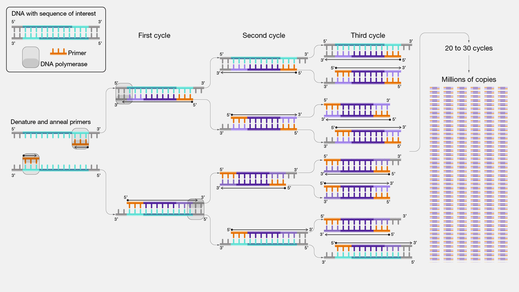

Figura 1. Reação em Cadeia da Polimerase